# GEMS X003.4 Spatial Regression

[figure not shown]

# **Spatial Regression**

**Instructors:**  
Yuan Chai (chaix026@umn.edu)  
Ali Joglekar (joglekar@umn.edu)

## Method of Delivery

- Workshop text, images and R code are all contained within a R Markdown file in the github repository. You need to have R and RStudio installed on your machine to participate
- A recording of the workshop will be posted on Canvas
- Please download any desired materials, as we cannot guarantee access to the Canvas course beyond 3 months.

## Module Outline:

- Spatial Dependence
  - Exercise 1
- Spatial Weight Objects
  - Exercise 2
- Spatial Autocorrelation
  - Exercise 3
- Spatial Regression
  - Exercise 4

## **Load R Libraries**

```r
# Install and load packages needed for this workshop

packages_to_load <- c("sf", "spdep", "spatialreg", "tmap")

for ( package in packages_to_load ) {
    # Check if package is already installed, if not, install and load the package
    if (!require(package, character.only=T, quietly=T, warn.conflicts=F)) {
        install.packages(package)
        suppressPackageStartupMessages(library(package, character.only=T, quietly=T, warn.conflicts=F))
    }
}
```

```
## To access larger datasets in this package, install the spDataLarge
## package with: `install.packages('spDataLarge',
## repos='https://nowosad.github.io/drat/', type='source')`
```

```
## Breaking News: tmap 3.x is retiring. Please test v4, e.g. with
## remotes::install_github('r-tmap/tmap')
```

Note: For your own work, once packages are installed, it is recommended to just use library() to load your packages

```
# Spatial data libraries
library(terra)
library(sf)
library(spdep)

# Spatial regression libraries
library(spatialreg)

# Plotting libraries
library(tmap)
```

## Data

For this workshop, a pseudo dataset representing hypothetical pest stress for selected Minnesota counties are created and saved in the directory `./data/shp/mnp`.  
For the hands-on exercises, you will be using a dataset downloaded from the Malawi Living Standard Measurement Survey Integrated Household Sample (LSMS-IHS) Data Wave 5 Data (available from https://microdata.worldbank.org/index.php/catalog/3818 ). The data has been downloaded, cleaned, transformed, and saved in the directory `./data/shp/MWI`.

### Attribution

The following material draws heavily from [Spatial Data Science](https://rspatial.org/raster/analysis/3-spauto.html) and some other online sources ([link 1](http://www.econ.uiuc.edu/~lab/workshop/Spatial_in_R.html), [link 2](https://www.r-bloggers.com/2019/09/spatial-regression-in-r-part-1-spamm-vs-glmmtmb/), [link 3](https://rpubs.com/quarcs-lab/tutorial-spatial-regression)).

## **Spatial Dependence**

When dealing with space, one must bear in mind Tobler’s first law of geography

> **“Everything is related to everything else, but close things are more related than things that are far apart”**  
> –Tobler (1979)

**Example**

Pest pressure for Minnesota, notice how the pest pressure are not randomly distributed across the study area

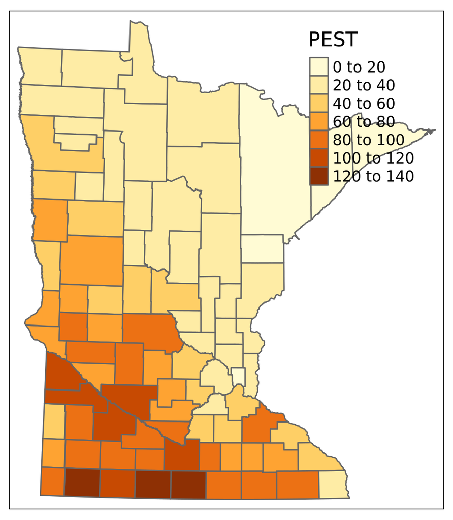

**Basic Steps** for answering spatial regression problems:

1. Decide how points/polygons are linked in space (and time)
2. Specify a spatial weights matrix
3. Run OLS
4. Check for spatial autocorrelation (residual)
5. Run spatial regression

In this workshop we’ll introduce you to these basic steps, including specification of spatial dependence, specification tests to detect spatial dependence in regressions models and basic regression models that incorporate spatial dependence.

### **Measuring spatial association and correlation**

An important step in spatial statistics and modelling is to get a measure of the spatial influence between geographic objects.  
This can be expressed as a function of *adjacency*, *closeness* or *(inverse) distance*, and is often expressed as a spatial weights matrix.

### **Neighbor Criterion**

The specification of the neighboring set is quite arbitrary and there’s a wide range of suggestions in the literature.

In `spdep` package, neighbor relationships between *n* observations are represented by an `nb` object class

#### **Contiguity-based neighbors:**

Neighboring polygons “touch” a focal polygon

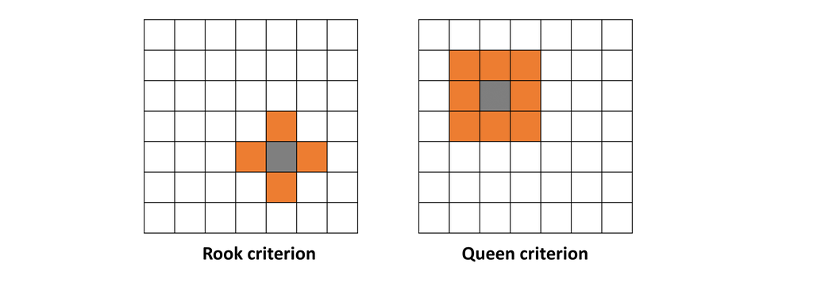

1. **Rook criterion**: neighboring polygons must share a line segment with focal polygon
2. **Queen criterion**: neighboring polygons must share a vertex with focal polygon

#### **Distance-based neighbors:**

Neighboring polygons within a given proximity threshold to a focal polygon

1. **K-nearest neighbors** retains K nearest neighbors for each focal polygon
2. **Neighborhood contiguity by distance** retains the neighbors for each focal polygon within a fixed distance band

**Note:** Distances are measured between polygon centroids.  
If your data are in geographic coordinate system, you can supply the argument `longlat = TRUE` to use great circle distances

**Example:** Pest pressure (hypothetical dataset) for selected Minnesota counties

```r
# read in our example shape file: pest pressure for selected MN counties
mnp <- st_read("./data/shp/mnp")
mnp <- st_as_sf(mnp)
str(mnp)
```

```
## Classes 'sf' and 'data.frame':   41 obs. of  5 variables:
##  $ COUNTYFIPS: chr  "013" "015" "019" "023" ...
##  $ COUNTYNAME: chr  "Blue Earth" "Brown" "Carver" "Chippewa" ...
##  $ HOST      : num  7.07 5.33 5.93 5.66 5.66 ...
##  $ PEST      : num  101.4 87.9 45.4 74.1 90.9 ...
##  $ geometry  :sfc_POLYGON of length 41; first list element: List of 1
##   ..$ : num [1:1064, 1:2] 390507 390512 390549 390669 390892 ...
##   ..- attr(*, "class")= chr [1:3] "XY" "POLYGON" "sfg"
##  - attr(*, "sf_column")= chr "geometry"
##  - attr(*, "agr")= Factor w/ 3 levels "constant","aggregate",..: NA NA NA NA
##   ..- attr(*, "names")= chr [1:4] "COUNTYFIPS" "COUNTYNAME" "HOST" "PEST"
```

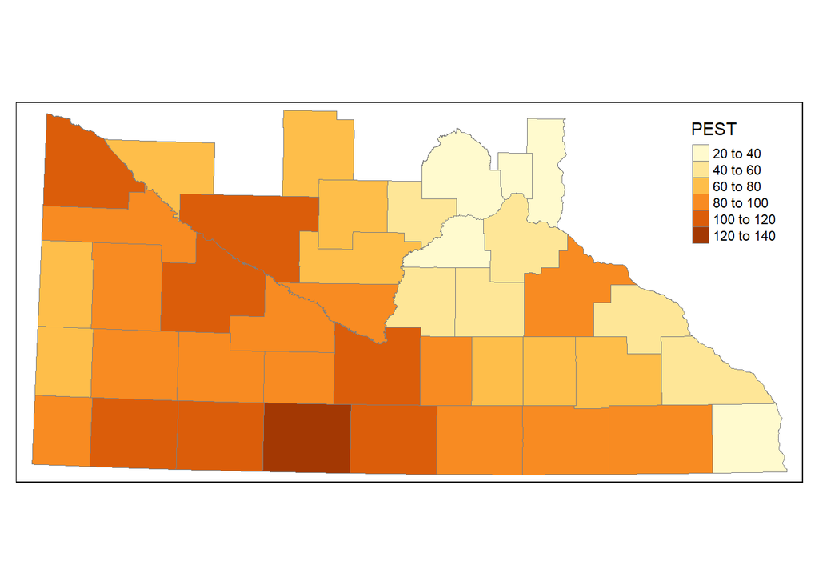

```r
# plot the PEST variable

tm_shape(mnp) +
tm_polygons(col="PEST", border.col="grey50", lwd=.4)
```

```r
# calculate neighboring using Queen's case (default)
mnp_nbq <- poly2nb(mnp, queen=TRUE)
mnp_nbq
```

```
## Neighbour list object:
## Number of regions: 41
## Number of nonzero links: 190
## Percentage nonzero weights: 11.3028
## Average number of links: 4.634146
```

```r
# structure of a spatial neighbor object
str(mnp_nbq)
```

```
## List of 41
##  $ : int [1:7] 2 8 16 20 24 37 39
##  $ : int [1:6] 1 5 24 29 30 39
##  $ : int [1:4] 12 19 33 34
##  $ : int [1:3] 15 30 41
##  $ : int [1:6] 2 14 23 25 29 39
##  $ : int [1:6] 11 12 28 31 33 38
##  $ : int [1:5] 11 22 26 31 35
##  $ : int [1:4] 1 10 20 37
##  $ : int [1:4] 13 22 26 40
##  $ : int [1:4] 8 22 35 37
##  $ : int [1:5] 6 7 26 31 36
##  $ : int [1:4] 3 6 28 33
##  $ : int [1:2] 9 40
##  $ : int [1:4] 5 20 25 39
```

[output cut: 32 more lines]

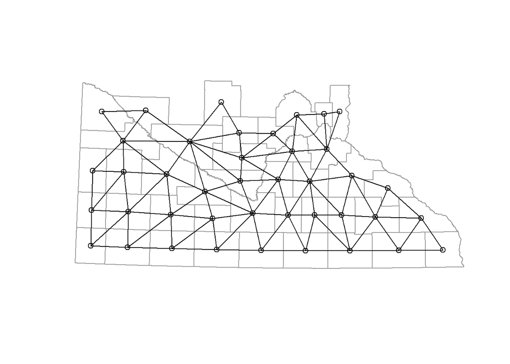

```r
# quick plot
plot(mnp$geometry, border = "grey60")
plot(mnp_nbq, st_coordinates(st_centroid(st_geometry(mnp))), add=T)
```

```r
# calculate neighboring using Rook's case
mnp_nbr <- poly2nb(mnp, queen=FALSE)
mnp_nbr
```

```
## Neighbour list object:
## Number of regions: 41
## Number of nonzero links: 190
## Percentage nonzero weights: 11.3028
## Average number of links: 4.634146
```

```r
# K-nearest neighbors
mnp_nbk <- knn2nb(knearneigh(st_centroid(st_geometry(mnp)), k=3))
mnp_nbk
```

```
## Neighbour list object:
## Number of regions: 41
## Number of nonzero links: 123
## Percentage nonzero weights: 7.317073
## Average number of links: 3
## Non-symmetric neighbours list
```

```r
# Neighborhood continuity by distance
mnp_nbd <- dnearneigh(st_centroid(st_geometry(mnp)), d1 = 0, d2 = 100000) # neighbors within 100 km
mnp_nbd
```

```
## Neighbour list object:
## Number of regions: 41
## Number of nonzero links: 518
## Percentage nonzero weights: 30.81499
## Average number of links: 12.63415
```

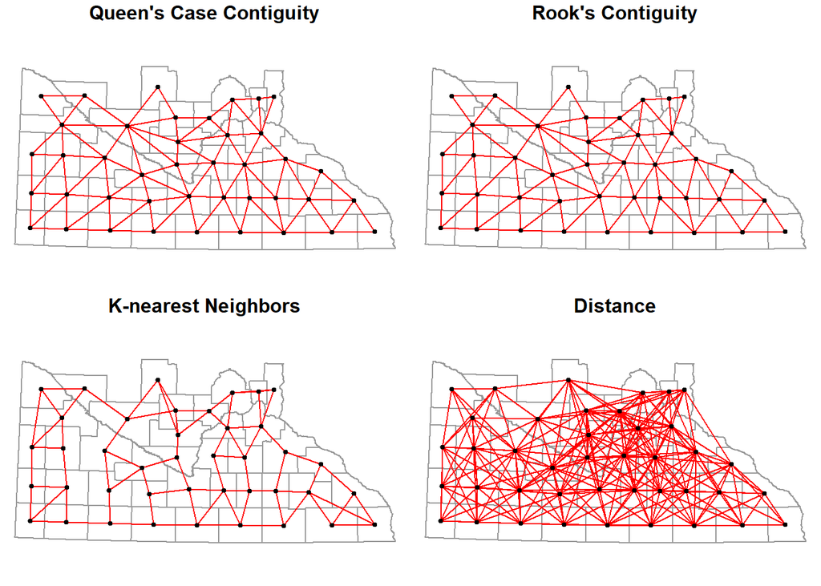

```r
# Plot
par(mfrow = c(2, 2))
par(mai=c(0,0,0.2,0))

plt_coord <- st_coordinates(st_centroid(st_geometry(mnp)))

plot(mnp$geometry, border = "grey60", main = "Queen's Case Contiguity")
plot(mnp_nbq, plt_coord, pch = 19, cex = 0.6, col="red", add = TRUE)

plot(mnp$geometry, border = "grey60", main = "Rook's Contiguity")
plot(mnp_nbr, plt_coord, pch = 19, cex = 0.6, col="red", add = TRUE)

plot(mnp$geometry, border = "grey60", main = "K-nearest Neighbors")
plot(mnp_nbk, plt_coord, pch = 19, cex = 0.6, col="red", add = TRUE)

plot(mnp$geometry, border = "grey60", main = "Distance")
plot(mnp_nbd, plt_coord, pch = 19, cex = 0.6, col="red", add = TRUE)
```

### **Exercise 1: Calculating neighbor objects**

In this exercise, we will first read in a shape file which contains the Malawi LSMS data and then create various neighbor objects.

**Step 1:** Use the `st_read()` function to read in shape file from the `'./data/shp/MWI/` directory.

```r
# Your answer
```

**Step 2:** Calculate a neighbor object for Malawi using the queen’s case, rook’s case, k-nearest neighbor & distance.

> Note, your Malawi object has a long/lat projection, so you want to look up the long/lat argument in distance-based metrics.

```r
# Your answer
```

**Step 3:** Print your neighbor objects or use the `summary()` function to explore these objects. What differences do you see?

```r
# Your answer
```

**Step 4:** Plot your neighbor objects to explore these objects. What differences do you see?

```r
# Your answer
```

```
# Possible answer:

# Step 1:
# Read MWI shape file
mwi_sf <- st_read("./data/shp/MWI") #shapefiles called only using data source name (dsn)
mwi_sf


# Step 2:
#neighbor objects
#-------------
mwi_nbq <- poly2nb(mwi_sf) #queen's case by default
mwi_nbr <- poly2nb(mwi_sf, queen = FALSE) #rook's case
mwi_nbk <- knn2nb(knearneigh(st_centroid(st_geometry(mwi_sf)), k = 3)) #3 nearest neighbors
mwi_nbd <- dnearneigh(st_centroid(st_geometry(mwi_sf)), d1 = 0, d2 = 1, longlat = TRUE) #neighbors within 1 degree

# Step 3:
summary(mwi_nbq)
summary(mwi_nbr)
summary(mwi_nbk)
summary(mwi_nbd)



# Step 4:
par(mfrow = c(1, 4))
par(mar=c(0,0,2,0))

mwi_coord <- st_coordinates(st_centroid(st_geometry(mwi_sf)))

plot(mwi_sf$geometry, border = "grey60", main = "Queen's Case Contiguity")
plot(mwi_nbq, mwi_coord, pch = 19, cex = 0.6, col="red", add = TRUE)

plot(mwi_sf$geometry, border = "grey60", main = "Rook's Contiguity")
plot(mwi_nbr, mwi_coord, pch = 19, cex = 0.6, col="red", add = TRUE)

plot(mwi_sf$geometry, border = "grey60", main = "K-nearest Neighbors")
plot(mwi_nbk, mwi_coord, pch = 19, cex = 0.6, col="red", add = TRUE)

plot(mwi_sf$geometry, border = "grey60", main = "Distance")
plot(mwi_nbd, mwi_coord, pch = 19, cex = 0.6, col="red", add = TRUE)
```

## **Spatial Weight Objects**

Spatial weights are a list of weights indexed by a list of neighbors.

- Useful to have a formalized way of evaluating spatial relationships
- For a set of *n* units, each observation *i* can be potentially related to all the (*n* - 1) possible units
- In practice we can usually assume that some interactions are more important than others
- Often use a matrix to represent the connectivities between observations

If we know little about the assumed spatial process, we try to avoid moving far from the binary representation of a weight of unity for neighbors, and zero otherwise.

In `spdep` package, the `nb2listw` function takes a neighbors list (`nb`) object and converts it into a weights (`listw`) object.

- For `style="W"` (default), weights vary between 1 divided by the largest and smallest numbers of neighbors, and the sum of weights for each areal entity equal 1 (**row standardization**).
- For `style="B"` – ‘binary’ – weights retain unity for each neighbor relationship, and the sum of weights for areas differ according to the numbers of neighbor areas have.

Conventionally we always have a 0 in the main diagonal in that each area is not considered a neighbor to itself

**Example:** Creating Spatial Weight Objects

```r
# Spatial Weight Objects -- Row Standardized
mnp_lw_w <- nb2listw(mnp_nbq)
summary(mnp_lw_w)
```

```
## Characteristics of weights list object:
## Neighbour list object:
## Number of regions: 41
## Number of nonzero links: 190
## Percentage nonzero weights: 11.3028
## Average number of links: 4.634146
## Link number distribution:
##
##  2  3  4  5  6  7  8
##  4  5 11  7 11  2  1
## 4 least connected regions:
## 13 15 21 38 with 2 links
## 1 most connected region:
## 30 with 8 links
##
## Weights style: W
## Weights constants summary:
##    n   nn S0       S1       S2
## W 41 1681 41 19.07179 168.2544
```

```r
# structure of the Spatial Weight Objects
str(mnp_lw_w)
```

```
## List of 3
##  $ style     : chr "W"
##  $ neighbours:List of 41
##   ..$ : int [1:7] 2 8 16 20 24 37 39
##   ..$ : int [1:6] 1 5 24 29 30 39
##   ..$ : int [1:4] 12 19 33 34
##   ..$ : int [1:3] 15 30 41
##   ..$ : int [1:6] 2 14 23 25 29 39
##   ..$ : int [1:6] 11 12 28 31 33 38
##   ..$ : int [1:5] 11 22 26 31 35
##   ..$ : int [1:4] 1 10 20 37
##   ..$ : int [1:4] 13 22 26 40
##   ..$ : int [1:4] 8 22 35 37
##   ..$ : int [1:5] 6 7 26 31 36
##   ..$ : int [1:4] 3 6 28 33
##   ..$ : int [1:2] 9 40
##   ..$ : int [1:4] 5 20 25 39
##   ..$ : int [1:2] 4 41
##   ..$ : int [1:6] 1 24 31 33 34 37
##   ..$ : int [1:3] 18 27 41
##   ..$ : int [1:5] 17 23 27 29 41
##   ..$ : int [1:4] 3 21 30 34
##   ..$ : int [1:4] 1 8 14 39
##   ..$ : int [1:2] 19 30
##   ..$ : int [1:5] 7 9 10 26 35
##   ..$ : int [1:6] 5 18 25 27 29 32
##   ..$ : int [1:5] 1 2 16 30 34
##   ..$ : int [1:4] 5 14 23 32
##   ..$ : int [1:6] 7 9 11 22 36 40
##   ..$ : int [1:4] 17 18 23 32
##   ..$ : int [1:3] 6 12 38
##   ..$ : int [1:6] 2 5 18 23 30 41
##   ..$ : int [1:8] 2 4 19 21 24 29 34 41
##   ..$ : int [1:7] 6 7 11 16 33 35 37
##   ..$ : int [1:3] 23 25 27
##   ..$ : int [1:6] 3 6 12 16 31 34
##   ..$ : int [1:6] 3 16 19 24 30 33
##   ..$ : int [1:5] 7 10 22 31 37
##   ..$ : int [1:3] 11 26 40
##   ..$ : int [1:6] 1 8 10 16 31 35
```

[output cut: 44 more lines]

```
##   ..$ : num [1:5] 0.2 0.2 0.2 0.2 0.2
##   ..$ : num [1:3] 0.333 0.333 0.333
##   ..$ : num [1:6] 0.167 0.167 0.167 0.167 0.167 ...
##   ..$ : num [1:2] 0.5 0.5
##   ..$ : num [1:5] 0.2 0.2 0.2 0.2 0.2
##   ..$ : num [1:4] 0.25 0.25 0.25 0.25
##   ..$ : num [1:6] 0.167 0.167 0.167 0.167 0.167 ...
##   ..- attr(*, "mode")= chr "binary"
##   ..- attr(*, "W")= logi TRUE
##   ..- attr(*, "comp")=List of 1
##   .. ..$ d: num [1:41] 7 6 4 3 6 6 5 4 4 4 ...
##  - attr(*, "class")= chr [1:2] "listw" "nb"
##  - attr(*, "region.id")= chr [1:41] "1" "2" "3" "4" ...
##  - attr(*, "call")= language nb2listw(neighbours = mnp_nbq)
##  - attr(*, "zero.policy")= logi FALSE
```

```r
# Summary of the weights
summary(unlist(mnp_lw_w$weights))
```

```
##    Min. 1st Qu.  Median    Mean 3rd Qu.    Max.
##  0.1250  0.1667  0.2000  0.2158  0.2500  0.5000
```

```r
# Sum of the weights
sapply(mnp_lw_w$weights, sum)
```

```
##  [1] 1 1 1 1 1 1 1 1 1 1 1 1 1 1 1 1 1 1 1 1 1 1 1 1 1 1 1 1 1 1 1 1 1 1 1 1 1 1
## [39] 1 1 1
```

```r
# A matrix view of the weight assigned
round(listw2mat(mnp_lw_w), 2)
```

```
##    [,1] [,2] [,3] [,4] [,5] [,6] [,7] [,8] [,9] [,10] [,11] [,12] [,13] [,14]
## 1  0.00 0.14 0.00 0.00 0.00 0.00 0.00 0.14 0.00  0.00  0.00  0.00  0.00  0.00
## 2  0.17 0.00 0.00 0.00 0.17 0.00 0.00 0.00 0.00  0.00  0.00  0.00  0.00  0.00
## 3  0.00 0.00 0.00 0.00 0.00 0.00 0.00 0.00 0.00  0.00  0.00  0.25  0.00  0.00
## 4  0.00 0.00 0.00 0.00 0.00 0.00 0.00 0.00 0.00  0.00  0.00  0.00  0.00  0.00
## 5  0.00 0.17 0.00 0.00 0.00 0.00 0.00 0.00 0.00  0.00  0.00  0.00  0.00  0.17
## 6  0.00 0.00 0.00 0.00 0.00 0.00 0.00 0.00 0.00  0.00  0.17  0.17  0.00  0.00
## 7  0.00 0.00 0.00 0.00 0.00 0.00 0.00 0.00 0.00  0.00  0.20  0.00  0.00  0.00
## 8  0.25 0.00 0.00 0.00 0.00 0.00 0.00 0.00 0.00  0.25  0.00  0.00  0.00  0.00
## 9  0.00 0.00 0.00 0.00 0.00 0.00 0.00 0.00 0.00  0.00  0.00  0.00  0.25  0.00
## 10 0.00 0.00 0.00 0.00 0.00 0.00 0.00 0.25 0.00  0.00  0.00  0.00  0.00  0.00
## 11 0.00 0.00 0.00 0.00 0.00 0.20 0.20 0.00 0.00  0.00  0.00  0.00  0.00  0.00
## 12 0.00 0.00 0.25 0.00 0.00 0.25 0.00 0.00 0.00  0.00  0.00  0.00  0.00  0.00
## 13 0.00 0.00 0.00 0.00 0.00 0.00 0.00 0.00 0.50  0.00  0.00  0.00  0.00  0.00
## 14 0.00 0.00 0.00 0.00 0.25 0.00 0.00 0.00 0.00  0.00  0.00  0.00  0.00  0.00
```

[output cut: 153 more lines]

```r
# Spatial Weight Objects -- Binary
mnp_lw_b <- nb2listw(mnp_nbq, style="B")
summary(mnp_lw_b)
```

```
## Characteristics of weights list object:
## Neighbour list object:
## Number of regions: 41
## Number of nonzero links: 190
## Percentage nonzero weights: 11.3028
## Average number of links: 4.634146
## Link number distribution:
##
##  2  3  4  5  6  7  8
##  4  5 11  7 11  2  1
## 4 least connected regions:
## 13 15 21 38 with 2 links
## 1 most connected region:
## 30 with 8 links
##
## Weights style: B
## Weights constants summary:
##    n   nn  S0  S1   S2
## B 41 1681 190 380 3880
```

```r
# Structure of the spatial weight objects
str(mnp_lw_b)
```

```
## List of 3
##  $ style     : chr "B"
##  $ neighbours:List of 41
##   ..$ : int [1:7] 2 8 16 20 24 37 39
##   ..$ : int [1:6] 1 5 24 29 30 39
##   ..$ : int [1:4] 12 19 33 34
##   ..$ : int [1:3] 15 30 41
##   ..$ : int [1:6] 2 14 23 25 29 39
##   ..$ : int [1:6] 11 12 28 31 33 38
##   ..$ : int [1:5] 11 22 26 31 35
##   ..$ : int [1:4] 1 10 20 37
##   ..$ : int [1:4] 13 22 26 40
##   ..$ : int [1:4] 8 22 35 37
##   ..$ : int [1:5] 6 7 26 31 36
##   ..$ : int [1:4] 3 6 28 33
##   ..$ : int [1:2] 9 40
##   ..$ : int [1:4] 5 20 25 39
##   ..$ : int [1:2] 4 41
##   ..$ : int [1:6] 1 24 31 33 34 37
##   ..$ : int [1:3] 18 27 41
##   ..$ : int [1:5] 17 23 27 29 41
##   ..$ : int [1:4] 3 21 30 34
##   ..$ : int [1:4] 1 8 14 39
##   ..$ : int [1:2] 19 30
##   ..$ : int [1:5] 7 9 10 26 35
##   ..$ : int [1:6] 5 18 25 27 29 32
##   ..$ : int [1:5] 1 2 16 30 34
##   ..$ : int [1:4] 5 14 23 32
##   ..$ : int [1:6] 7 9 11 22 36 40
##   ..$ : int [1:4] 17 18 23 32
##   ..$ : int [1:3] 6 12 38
##   ..$ : int [1:6] 2 5 18 23 30 41
##   ..$ : int [1:8] 2 4 19 21 24 29 34 41
##   ..$ : int [1:7] 6 7 11 16 33 35 37
##   ..$ : int [1:3] 23 25 27
##   ..$ : int [1:6] 3 6 12 16 31 34
##   ..$ : int [1:6] 3 16 19 24 30 33
##   ..$ : int [1:5] 7 10 22 31 37
##   ..$ : int [1:3] 11 26 40
##   ..$ : int [1:6] 1 8 10 16 31 35
```

[output cut: 42 more lines]

```
##   ..$ : num [1:6] 1 1 1 1 1 1
##   ..$ : num [1:6] 1 1 1 1 1 1
##   ..$ : num [1:5] 1 1 1 1 1
##   ..$ : num [1:3] 1 1 1
##   ..$ : num [1:6] 1 1 1 1 1 1
##   ..$ : num [1:2] 1 1
##   ..$ : num [1:5] 1 1 1 1 1
##   ..$ : num [1:4] 1 1 1 1
##   ..$ : num [1:6] 1 1 1 1 1 1
##   ..- attr(*, "mode")= chr "binary"
##   ..- attr(*, "B")= logi TRUE
##  - attr(*, "class")= chr [1:2] "listw" "nb"
##  - attr(*, "region.id")= chr [1:41] "1" "2" "3" "4" ...
##  - attr(*, "call")= language nb2listw(neighbours = mnp_nbq, style = "B")
##  - attr(*, "zero.policy")= logi FALSE
```

```r
# Summary of the weights
summary(unlist(mnp_lw_b$weights))
```

```
##    Min. 1st Qu.  Median    Mean 3rd Qu.    Max.
##       1       1       1       1       1       1
```

```r
# Sum of weights by list
sapply(mnp_lw_b$weights, sum)
```

```
##  [1] 7 6 4 3 6 6 5 4 4 4 5 4 2 4 2 6 3 5 4 4 2 5 6 5 4 6 4 3 6 8 7 3 6 6 5 3 6 2
## [39] 5 4 6
```

```r
# Matrix view of the weights (only showing first 10 rows x 10cols)
listw2mat(mnp_lw_b)
```

```
##    [,1] [,2] [,3] [,4] [,5] [,6] [,7] [,8] [,9] [,10] [,11] [,12] [,13] [,14]
## 1     0    1    0    0    0    0    0    1    0     0     0     0     0     0
## 2     1    0    0    0    1    0    0    0    0     0     0     0     0     0
## 3     0    0    0    0    0    0    0    0    0     0     0     1     0     0
## 4     0    0    0    0    0    0    0    0    0     0     0     0     0     0
## 5     0    1    0    0    0    0    0    0    0     0     0     0     0     1
## 6     0    0    0    0    0    0    0    0    0     0     1     1     0     0
## 7     0    0    0    0    0    0    0    0    0     0     1     0     0     0
## 8     1    0    0    0    0    0    0    0    0     1     0     0     0     0
## 9     0    0    0    0    0    0    0    0    0     0     0     0     1     0
## 10    0    0    0    0    0    0    0    1    0     0     0     0     0     0
## 11    0    0    0    0    0    1    1    0    0     0     0     0     0     0
## 12    0    0    1    0    0    1    0    0    0     0     0     0     0     0
## 13    0    0    0    0    0    0    0    0    1     0     0     0     0     0
## 14    0    0    0    0    1    0    0    0    0     0     0     0     0     0
```

[output cut: 153 more lines]

### **Exercise 2: Spatial Weights Objects**

In this exercise, we build off results from Exercise 1 with our Malawi LSMS data and the spatial neighbor objects we created.

**Step 1:** Use the `nb2listw` function create a spatial weight object with **row-standardized** weights

```r
# Your answer
```

**Step 2:** Use the `nb2listw` function create a spatial weight object with **binary** weights

```r
# Your answer
```

**Step 3:** Compare the weight matrix between the **row-standardized** and **binary** type

```r
# Your answer
```

```
# Possible answer:

# Step 1:
mwi_lw_w <- nb2listw(mwi_nbq)
summary(mwi_lw_w)

# Step 2:
mwi_lw_b <- nb2listw(mwi_nbq, style="B")
summary(mwi_lw_b)

# Step 3:
# Matrix view of the weights
listw2mat(mwi_lw_w)
listw2mat(mwi_lw_b)
```

## **Spatial autocorrelation**

- **Positve spatial autocorrelation:** similar values are close to each other
- **Negative spatial autocorrelation:** similar values are distant from each other
- **Random spatial autocorrelation:** similar values are neither close nor distant from each other

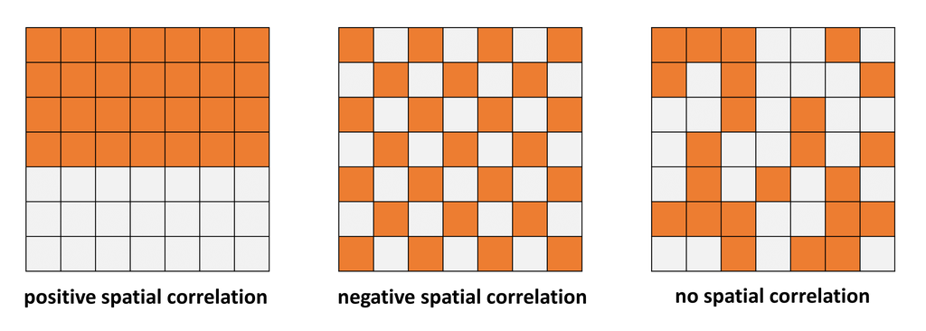

#### Global Indicators of Spatial Association

**Moran’s I** (`moran.test()`) is perhaps the most common global test. For other test, see also [Geary’s C](https://en.wikipedia.org/wiki/Geary%27s_C) [(`geary.test()`)](https://r-spatial.github.io/spdep/reference/geary.test.html)

- Measures the linear association between a value and a weighted average of its neighbors
- If there is no spatial clustering in *y*, then the spatial lag of *y* should not vary systematically with *y*

**General approach for Moran’s I**:

$$I = \frac{n}{\sum_{i=1}^n\sum_{j=1}^n w_{ij}}
\frac{\sum_{i=1}^n\sum_{j=1}^n w_{ij} (y_i - \bar y)(y_j - \bar
y)}{\sum_{i=1}^n (y_i - \bar y)^2}$$
where $y_i$ is the $i$th observation, $\bar y$ is the mean of the variable of interest, and $w_{ij}$ is the spatial weight of the link between $i$ and $j$.

- Result is a standard deviate
- Compare with normal distribution to find probability value of observed statistic under the null hypothesis of no spatial dependence
- Most often the test is one-sided, with an alternative hypothesis of observed statistic being significantly greater than its expected value
- Outcomes depend on the choices made

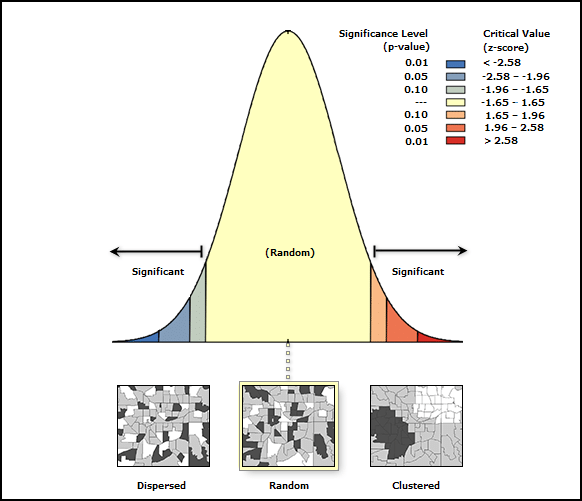

**Moran’s I Statistics**

```r
moran.test(mnp$PEST, listw = mnp_lw_w)
```

```
##
##  Moran I test under randomisation
##
## data:  mnp$PEST
## weights: mnp_lw_w
##
## Moran I statistic standard deviate = 5.7459, p-value = 4.572e-09
## alternative hypothesis: greater
## sample estimates:
## Moran I statistic       Expectation          Variance
##        0.55688019       -0.02500000        0.01025536
```

**Moran’s I Plot**  
Global tests for spatial autocorrelation calculated from local relationships between values observed at a spatial entity and its neighbors, for chosen weights

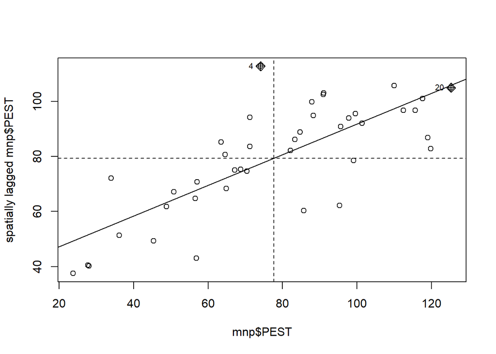

```r
moran.plot(mnp$PEST, listw = mnp_lw_w)
```

- Slope coefficient equal to global Moran’s I
- Plot is centered on the means

> Moran’s test and plot automatically calculates the lagged variable for you, but it’s possible to calculate lagged variable manually by multiplying the spatial weight matrix with the variable of interest

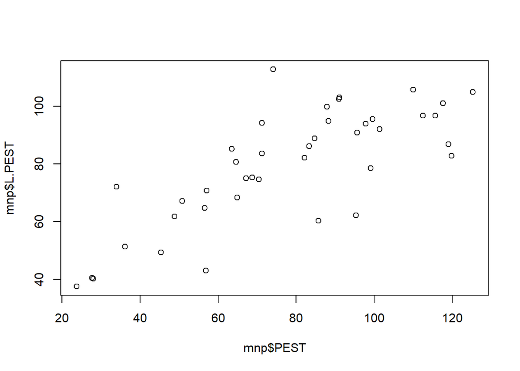

```r
# manually create a spatila lag for PEST variable
mnp$L.PEST <- lag.listw(mnp_lw_w, mnp$PEST)
plot(mnp$PEST, mnp$L.PEST)
```

### **Exercise 3: Calculating Moran’s I**

In this exercise, we will utilize the basic ideas we explored related to spatial autocorrelation to test spatial autocorrelation across multiple variables

**Step 1:** Use the `moran.test` function test the spatial autocorrelation for `poverty` variable

```r
# Your answer
```

**Step 2:** Use the `moran.plot` function plot the Moran’s I plot for `poverty` variable

```r
# Your answer
```

**Step 3:** Use the `moran.test` and `moran.plot` function plot the Moran’s I plot for other variables in the Malawi LSMS data (e.g., `croplnd`, `tobccHH`, etc)

```r
# Your answer
```

```
## Possible answer:

#Step 1:
moran.test(mwi_sf$poverty, listw=mwi_lw_w)

#Step 2:
moran.plot(mwi_sf$poverty, listw=mwi_lw_w)

# Step 3:
# croplnd
moran.test(mwi_sf$croplnd, listw=mwi_lw_w)
moran.plot(mwi_sf$croplnd, listw=mwi_lw_w)

# tobccHH
moran.test(mwi_sf$tobccHH, listw=mwi_lw_w)
moran.plot(mwi_sf$tobccHH, listw=mwi_lw_w)
```

## **Spatial Regression Model**

OLS assumes that the hypothesis of sphericity of the errors:

$$y = X\beta + \varepsilon \qquad \\$$

1. Constant elements on the main diagonal of the variance-covariance matrix (homoscedasticity)
2. Zero value of the off-diagonal elements of the variance-covariance matrix (absence of autocorrelation)

$$\begin{align}
E(\epsilon \epsilon ') &= \begin{bmatrix}
\sigma^2 & 0 & \dots & 0\\
0 & \sigma^2 & \dots & 0\\
\vdots & \vdots & \vdots & 0\\
0 & 0 & \dots & \sigma^2
\end{bmatrix}
\end{align}$$

#### **Spatial Regression Models**

Spatial observations typically have heteroskadastic errors and autocorrelation  
A full generalized spatial regression model with all types of spatial lag effects takes the form:

$$y = \rho W_1y + X\beta + W_2X\gamma + u \qquad |\rho| < 1$$

$$u = \lambda W_3u + \varepsilon \qquad |\lambda| < 1$$
with $X$ a matrix of non-stochastic regressors, $W_i$ a weight matrix exogenously given, $\beta$ and $\gamma$ are vectors of regression parameters, $\varepsilon \sim N(0,\sigma_\varepsilon ^2I_n)$.

The scalar parameters $\rho$ (spatial autoregressive coefficient) and $\lambda$ (spatial autocorrelation coefficient) measure the strength of dependence between units

The $|\cdot| < 1$ restrictions on $\rho$ and $\lambda$ hold if $W_i$ is row-standardized.

Equation (1) considers endogenous spatial lags among the dependent variable, $W_1y$, and the exogenous spatial lags among the independent variables, $W_2X$

Equation (2) considers interaction effects among the the stochastic disturbance term of different units, $W_3u$

In theory, no need that the three weight matrices are the same, although difficult to justify a different choice in practice, $W_i = W$

### **Spatial Regression Model Specifications**

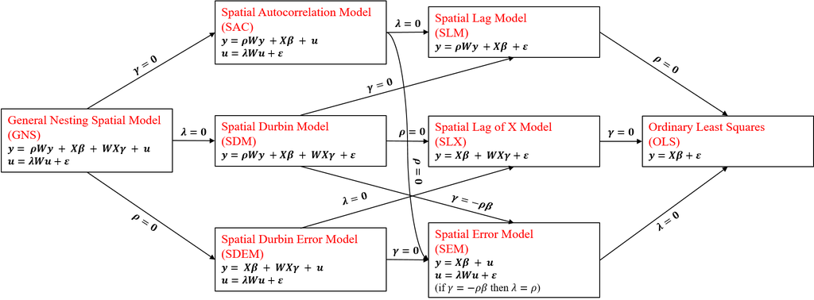

1. Spatial Error Model (SEM): $\rho = 0$; $\gamma = 0$; $\lambda \neq 0$
   $$\begin{array}{l}
   y = X\beta + u \\
   u = \lambda Wu + \varepsilon
   \end{array}$$
2. Spatial Lag of X Model (SLX): $\rho = 0$ $\gamma \neq 0$ $\lambda = 0$
   $$y = X\beta + WX\gamma + \varepsilon$$
3. Spatial Lag Model (SLM): $\rho \neq 0$; $\gamma = 0$; $\lambda = 0$
   $$y = \rho Wy + X\beta + \varepsilon$$
4. Spatial Durbin Error Model (SDEM): $\rho = 0$; $\gamma \neq 0$; $\lambda \neq 0$
   $$\begin{array}{l}
   y = X\beta + WX\gamma + u \\
   u = \lambda Wu + \varepsilon
   \end{array}$$
5. Spatial Durbin Model (SDM): $\rho \neq 0$; $\gamma \neq 0$; $\lambda = 0$
   $$y = \rho Wy + X\beta + WX\gamma + \varepsilon$$
6. Spatial Autocorrelation Model (SAC): $\rho \neq 0$ ; $\gamma = 0$; $\lambda \neq 0$
   $$\begin{array}{l}
   y = \rho Wy + X\beta + u \\
   u = \lambda Wu + \varepsilon
   \end{array}$$
7. General Nesting Spatial Model (GNS): $\rho \neq 0$; $\gamma \neq 0$; $\lambda \neq 0$
   $$\begin{array}{l}
   y = \rho Wy + X\beta + WX\gamma + u \\
   u = \lambda Wu + \varepsilon
   \end{array}$$

```r
# Spatial Lag Model (SLM)
mnp_slm <- lagsarlm(PEST ~ HOST, data=mnp, listw =mnp_lw_w)
summary(mnp_slm)
```

```
##
## Call:lagsarlm(formula = PEST ~ HOST, data = mnp, listw = mnp_lw_w)
##
## Residuals:
##      Min       1Q   Median       3Q      Max
## -33.5168 -10.9092  -2.2456  12.3104  36.7360
##
## Type: lag
## Coefficients: (asymptotic standard errors)
##             Estimate Std. Error z value Pr(>|z|)
## (Intercept)  -7.8268    12.2700 -0.6379  0.52355
## HOST          4.6239     1.8741  2.4673  0.01361
##
## Rho: 0.72929, LR test value: 23.15, p-value: 1.4981e-06
## Asymptotic standard error: 0.10454
##     z-value: 6.9761, p-value: 3.034e-12
## Wald statistic: 48.667, p-value: 3.0339e-12
##
## Log likelihood: -178.4974 for lag model
## ML residual variance (sigma squared): 300.26, (sigma: 17.328)
## Number of observations: 41
## Number of parameters estimated: 4
## AIC: 364.99, (AIC for lm: 386.15)
## LM test for residual autocorrelation
## test value: 0.13445, p-value: 0.71386
```

```r
# Spatial Lag of X Model (SLX)
mnp_slx <- lmSLX(PEST ~ HOST, data=mnp, listw =mnp_lw_w)
summary(mnp_slx)
```

```
##
## Call:
## lm(formula = formula(paste("y ~ ", paste(colnames(x)[-1], collapse = "+"))),
##     data = as.data.frame(x), weights = weights)
##
## Residuals:
##     Min      1Q  Median      3Q     Max
## -56.352 -12.665   0.651  18.445  43.144
##
## Coefficients:
##             Estimate Std. Error t value Pr(>|t|)
## (Intercept)    3.776     30.015   0.126    0.901
## HOST           6.154      2.910   2.115    0.041 *
## lag.HOST       6.199      5.321   1.165    0.251
## ---
## Signif. codes:  0 '***' 0.001 '**' 0.01 '*' 0.05 '.' 0.1 ' ' 1
##
## Residual standard error: 25.47 on 38 degrees of freedom
## Multiple R-squared:  0.1943, Adjusted R-squared:  0.1519
## F-statistic: 4.582 on 2 and 38 DF,  p-value: 0.01649
```

```r
# Spatial Error Model (SEM)
mnp_sem <- errorsarlm(PEST ~ HOST, data=mnp, listw =mnp_lw_w)
summary(mnp_sem)
```

```
##
## Call:errorsarlm(formula = PEST ~ HOST, data = mnp, listw = mnp_lw_w)
##
## Residuals:
##      Min       1Q   Median       3Q      Max
## -30.5749 -12.2437  -3.9439  14.7767  36.9023
##
## Type: error
## Coefficients: (asymptotic standard errors)
##             Estimate Std. Error z value Pr(>|z|)
## (Intercept)  43.4216    16.0618  2.7034 0.006863
## HOST          4.8908     1.9611  2.4939 0.012635
##
## Lambda: 0.76063, LR test value: 23.067, p-value: 1.5646e-06
## Asymptotic standard error: 0.10127
##     z-value: 7.5109, p-value: 5.862e-14
## Wald statistic: 56.414, p-value: 5.8731e-14
##
## Log likelihood: -178.5391 for error model
## ML residual variance (sigma squared): 294.87, (sigma: 17.172)
## Number of observations: 41
## Number of parameters estimated: 4
## AIC: NA (not available for weighted model), (AIC for lm: 386.15)
```

```r
# Spatial Autocorrelation Model (SAC)
mnp_sac <- sacsarlm(PEST ~ HOST, data=mnp, listw =mnp_lw_w)
summary(mnp_sac)
```

```
##
## Call:sacsarlm(formula = PEST ~ HOST, data = mnp, listw = mnp_lw_w)
##
## Residuals:
##      Min       1Q   Median       3Q      Max
## -33.1040 -12.3426  -2.9261  14.0740  37.9550
##
## Type: sac
## Coefficients: (asymptotic standard errors)
##             Estimate Std. Error z value Pr(>|z|)
## (Intercept)  -1.5927    26.7277 -0.0596  0.95248
## HOST          5.1856     2.0948  2.4754  0.01331
##
## Rho: 0.60091
## Asymptotic standard error: 0.38404
##     z-value: 1.5647, p-value: 0.11765
## Lambda: 0.25273
## Asymptotic standard error: 0.57415
##     z-value: 0.44019, p-value: 0.6598
##
## LR test value: 23.332, p-value: 8.5823e-06
##
## Log likelihood: -178.4068 for sac model
## ML residual variance (sigma squared): 313.86, (sigma: 17.716)
## Number of observations: 41
## Number of parameters estimated: 5
## AIC: 366.81, (AIC for lm: 386.15)
```

```r
# Spatial Durbin Model (SDM)
mnp_sdm <- lagsarlm(PEST ~ HOST, data=mnp, listw=mnp_lw_w, type="mixed")
summary(mnp_sdm)
```

```
##
## Call:lagsarlm(formula = PEST ~ HOST, data = mnp, listw = mnp_lw_w,
##     type = "mixed")
##
## Residuals:
##     Min      1Q  Median      3Q     Max
## -32.714 -12.724  -2.866  13.580  36.689
##
## Type: mixed
## Coefficients: (asymptotic standard errors)
##             Estimate Std. Error z value Pr(>|z|)
## (Intercept) -0.30463   20.32052 -0.0150  0.98804
## HOST         4.94027    1.96683  2.5118  0.01201
## lag.HOST    -1.81091    3.69336 -0.4903  0.62391
##
## Rho: 0.74751, LR test value: 21.937, p-value: 2.8176e-06
## Asymptotic standard error: 0.10484
##     z-value: 7.13, p-value: 1.0041e-12
## Wald statistic: 50.836, p-value: 1.004e-12
##
## Log likelihood: -178.3848 for mixed model
## ML residual variance (sigma squared): 295.22, (sigma: 17.182)
## Number of observations: 41
## Number of parameters estimated: 5
## AIC: 366.77, (AIC for lm: 386.71)
## LM test for residual autocorrelation
## test value: 0.039267, p-value: 0.84292
```

```r
# Spatial Durbin Error Model (SDEM)
mnp_sdem <- errorsarlm(PEST ~ HOST, data=mnp, listw =mnp_lw_w, etype="emixed")
summary(mnp_sdem)
```

```
##
## Call:errorsarlm(formula = PEST ~ HOST, data = mnp, listw = mnp_lw_w,
##     etype = "emixed")
##
## Residuals:
##      Min       1Q   Median       3Q      Max
## -31.4411 -12.2407  -3.3291  14.8191  37.1042
##
## Type: error
## Coefficients: (asymptotic standard errors)
##             Estimate Std. Error z value Pr(>|z|)
## (Intercept)  32.8908    45.1525  0.7284  0.46635
## HOST          5.2162     2.3260  2.2426  0.02493
## lag.HOST      1.4447     5.7528  0.2511  0.80171
##
## Lambda: 0.75497, LR test value: 21.688, p-value: 3.2071e-06
## Asymptotic standard error: 0.10292
##     z-value: 7.3352, p-value: 2.2138e-13
## Wald statistic: 53.805, p-value: 2.2138e-13
##
## Log likelihood: -178.509 for error model
## ML residual variance (sigma squared): 295.56, (sigma: 17.192)
## Number of observations: 41
## Number of parameters estimated: 5
## AIC: NA (not available for weighted model), (AIC for lm: 386.71)
```

```r
# General Nesting Spatial Model (GNS)
mnp_gns <- sacsarlm(PEST ~ HOST, data=mnp, listw =mnp_lw_w, type="sacmixed")
summary(mnp_gns)
```

```
##
## Call:sacsarlm(formula = PEST ~ HOST, data = mnp, listw = mnp_lw_w,
##     type = "sacmixed")
##
## Residuals:
##      Min       1Q   Median       3Q      Max
## -32.6529 -12.2769  -3.1643  14.0342  37.3254
##
## Type: sacmixed
## Coefficients: (asymptotic standard errors)
##             Estimate Std. Error z value Pr(>|z|)
## (Intercept)  0.87484   23.45180  0.0373  0.97024
## HOST         5.07350    1.99444  2.5438  0.01096
## lag.HOST    -1.44673    4.69361 -0.3082  0.75791
##
## Rho: 0.69213
## Asymptotic standard error: 0.35108
##     z-value: 1.9714, p-value: 0.048675
## Lambda: 0.1178
## Asymptotic standard error: 0.64038
##     z-value: 0.18395, p-value: 0.85405
##
## LR test value: 23.417, p-value: 3.3059e-05
##
## Log likelihood: -178.3642 for sacmixed model
## ML residual variance (sigma squared): 303.76, (sigma: 17.429)
## Number of observations: 41
## Number of parameters estimated: 6
## AIC: 368.73, (AIC for lm: 386.15)
```

### **Spatial Econometric Models in Practice**

Different spatial econometric models are generally impossible to distinguish without assuming prior knowledge about the true data‐generating process, which is often not possessed in practice.

There is a large gap in the level of interest in different types of interaction effects between theoreticians and practitioners.

- Theoreticians are mainly interested in the SLM (also known as SAR) and SEM models, as well as the SAC model
- Theoreticians generally do not focus on spatial econometric models with exogenous interaction effects ($WX$) is because the estimation of such models doesn’t pose any econometric problems
  - Standard estimation techniques suffice under these circumstances
  - SDEM and SLX models are hardly considered or used in econometric-theoretic and empirical research

### Testing Spatial Autocorrelation

If ML strategy used for estimation, can explicitly express alternative hypothesis as Lagrange Multiplier of SEM or SLM

**SEM Alternative Hypothesis**:
$$\begin{align}
LM_{SEM} = \frac{n^2}{tr(W^TW + WW)}\left[
\frac{\hat\varepsilon^TW\hat\varepsilon}{\hat\varepsilon^T\hat\varepsilon}
\right]^2
\end{align}$$
which is simply square of the Moran I test multiplied by a standardization factor

**SLM Alternative Hypothesis**:
$$\begin{align}
LM_{SLM} = \frac{n^2}{Q}\left[
\frac{\hat\varepsilon^TW\hat\varepsilon}{\hat\varepsilon^T\hat\varepsilon}
\right]^2
\end{align}$$
with $Q=(WX\hat\beta)^T(I-M_x)\frac{WX\hat\beta}{\hat\sigma^2_\varepsilon}$, $M_x=X(X^TX)X^T$, $T=tr(W^TW + WW)$ and with $\hat\beta$ and $\hat\sigma^2_\varepsilon$ denoting the maximum likelihood estimators of the corresponding parameters.

Both $LM_{SLM}$ and $LM_{SEM}$ are asymptotically distributed, under the null, as a $\chi^2$ with 1 degree of freedom

Two test statistics are not independent of one another – can only test the alt hypothesis that errors follow a SEM model assuming no spatial lag component and vice versa

Anselin et al. (1996) proposed a robust version of both tests

**Robust SEM Alternative Hypothesis**:
$$RLM_{SEM} = \frac{1}{T(1-TQ))}\left[
\frac{n\hat\varepsilon^TW\hat\varepsilon}{\hat\varepsilon^T\hat\varepsilon}
- TQ^{-1}
\frac{n\hat\varepsilon^TWy}{\hat\varepsilon^T\hat\varepsilon}\right]^2$$

**Robust SLM Alternative Hypothesis**:
$$RLM_{SLM} = \frac{n^2}{Q-T}\left[
\frac{n\hat\varepsilon^TW\hat\varepsilon}{\hat\varepsilon^T\hat\varepsilon}
- \frac{n\hat\varepsilon^TWy}{\hat\varepsilon^T\hat\varepsilon}
\right]^2$$

> Note: The test results are highly dependent on your choice of neighboring critirion and spatial weights.

### **Summary: Decision tree for model selection via LM tests**

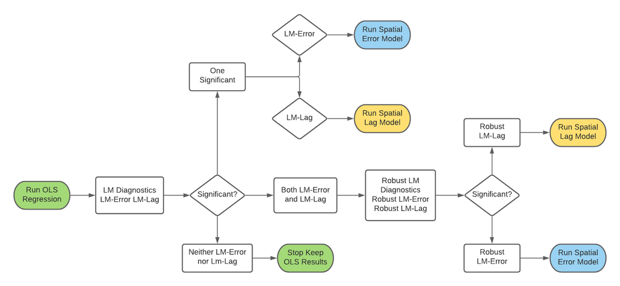

> Source: Anselin (1988), Burkey (2018)

### Implementation in R using Maximum Likelihood

Basic Steps:

1. Decide how points/polygons are linked in space (and time)
2. Specify a spatial weights matrix
3. Run OLS
4. Check for spatial autocorrelation (residual)
5. Run spatial regression

```r
# OLS
mnp_ols <- lm(PEST ~ HOST, data=mnp)
summary(mnp_ols)
```

```
##
## Call:
## lm(formula = PEST ~ HOST, data = mnp)
##
## Residuals:
##     Min      1Q  Median      3Q     Max
## -59.324 -14.625  -0.555  18.290  48.694
##
## Coefficients:
##             Estimate Std. Error t value Pr(>|t|)
## (Intercept)   33.018     16.531   1.997  0.05281 .
## HOST           7.481      2.690   2.782  0.00829 **
## ---
## Signif. codes:  0 '***' 0.001 '**' 0.01 '*' 0.05 '.' 0.1 ' ' 1
##
## Residual standard error: 25.58 on 39 degrees of freedom
## Multiple R-squared:  0.1655, Adjusted R-squared:  0.1441
## F-statistic: 7.737 on 1 and 39 DF,  p-value: 0.008292
```

```r
# Check for spatial autocorrelation
moran.test(mnp_ols$residuals, mnp_lw_w)
```

```
##
##  Moran I test under randomisation
##
## data:  mnp_ols$residuals
## weights: mnp_lw_w
##
## Moran I statistic standard deviate = 5.4207, p-value = 2.968e-08
## alternative hypothesis: greater
## sample estimates:
## Moran I statistic       Expectation          Variance
##        0.52185500       -0.02500000        0.01017729
```

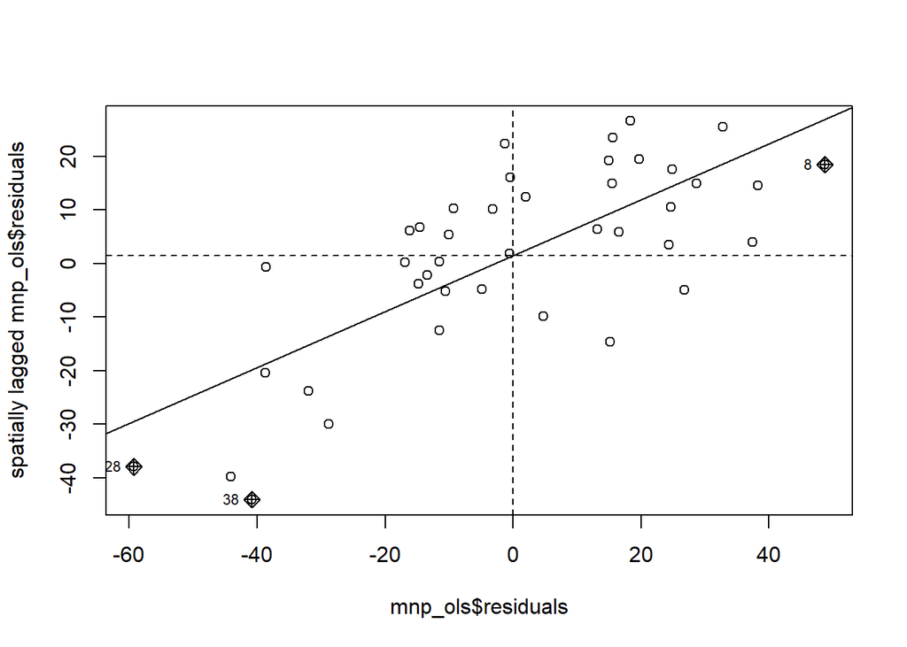

```r
moran.plot(mnp_ols$residuals, mnp_lw_w)
```

```r
summary(lm.LMtests(mnp_ols, mnp_lw_w, test=c("all")))
```

```
## Please update scripts to use lm.RStests in place of lm.LMtests
```

```
##  Rao's score (a.k.a Lagrange multiplier) diagnostics for spatial
##  dependence
## data:
## model: lm(formula = PEST ~ HOST, data = mnp)
## test weights: listw
##
##          statistic parameter   p.value
## RSerr     24.00358         1 9.616e-07 ***
## RSlag     25.25747         1 5.016e-07 ***
## adjRSerr   0.15985         1    0.6893
## adjRSlag   1.41374         1    0.2344
## SARMA     25.41732         2 3.025e-06 ***
## ---
## Signif. codes:  0 '***' 0.001 '**' 0.01 '*' 0.05 '.' 0.1 ' ' 1
```

```r
# Spatial Lag Model (SLM)
mnp_slm <- lagsarlm(PEST ~ HOST, data=mnp, listw =mnp_lw_w)
summary(mnp_slm)
```

```
##
## Call:lagsarlm(formula = PEST ~ HOST, data = mnp, listw = mnp_lw_w)
##
## Residuals:
##      Min       1Q   Median       3Q      Max
## -33.5168 -10.9092  -2.2456  12.3104  36.7360
##
## Type: lag
## Coefficients: (asymptotic standard errors)
##             Estimate Std. Error z value Pr(>|z|)
## (Intercept)  -7.8268    12.2700 -0.6379  0.52355
## HOST          4.6239     1.8741  2.4673  0.01361
##
## Rho: 0.72929, LR test value: 23.15, p-value: 1.4981e-06
## Asymptotic standard error: 0.10454
##     z-value: 6.9761, p-value: 3.034e-12
## Wald statistic: 48.667, p-value: 3.0339e-12
##
## Log likelihood: -178.4974 for lag model
## ML residual variance (sigma squared): 300.26, (sigma: 17.328)
## Number of observations: 41
## Number of parameters estimated: 4
## AIC: 364.99, (AIC for lm: 386.15)
## LM test for residual autocorrelation
## test value: 0.13445, p-value: 0.71386
```

### **Impacts Interpretation**

Mathematically, the notion of spillover can be thought as the derivative $\partial y_i/\partial x_j$

- Changes to explanatory variables in region $i$ impact the dependent variable in region $j \neq i$.
- For OLS model we have $\partial y_i/\partial x_j = 0$

Variation of variable $X$ observed in location $i$ has an effect on

1. The value of variable $y$ in the same location (*direct effect*), and
2. The value of variable $y$ observed in other locations (*indirect effect*)

```r
impacts(mnp_slm, listw = mnp_lw_w)
```

```
## Impact measures (lag, exact):
##        Direct Indirect    Total
## HOST 5.648269 11.43256 17.08083
```

### **Exercise 4: Spatial Regression**

In this exercise, we will conduct a spatial regression on our Malawi LSMS data

**Step 1:** Run an OLS regression of per capita consumption (`poverty`) as a function of cropland cultivated (`cropland`), livestock owned (`livstck`), share of off-farm income (`income`), years of education (`edu`), female head of household (`female`) and tobacco growing household (`tobccHH`).

```
> poverty ~ croplnd + livstck + income + edu + female + tobccHH
```

```r
# Your answer
```

**Step 2:** Run the LM lag model tests – which model do these tests indicate you should use?

```r
# Your answer
```

**Step 3:** Run your spatial regression model of choice.

```r
# Your answer
```

**Step 4:** Calculate impacts using `impacts(reg, listw)` function

```r
# Your answer
```

```
# Possible answer:

#Step 1:
mwi_ols <- lm(poverty ~ croplnd + livstck + income + edu + female + tobccHH, data = mwi_sf)
summary(mwi_ols)

# Step 2:
summary(lm.LMtests(mwi_ols, mwi_lw_w, test = c("all")))
# Look at the p.value to decide which model(s) to run

#Step 3:
mwi_slm <- lagsarlm(poverty ~ croplnd + livstck + income + edu + female + tobccHH,
                data = mwi_sf, listw = mwi_lw_w)
summary(mwi_slm)

#Step 4:
impacts(mwi_slm, listw = mwi_lw_w)
```